# Python ve Bilimsel Hesaplama

## Muhabbeti Koyulaştıralım

Benim derdim sayÄ± dizileri ve onlarla olan iÅŸlemler. Vektör, matris, lineer cebir, türev, vb. Yok mu bunlar için birÅŸeyler?

```python
import numpy # Bu mudur?
```

```python
a = numpy.array([[1,2,3],[4, 5, 6]])
a
```

```
array([[1, 2, 3],
       [4, 5, 6]])
```

```python
a[1,0] # satir,sÃ¼tun => 2. satÄ±r, 1. sÃ¼tun (indeks 0' dan baÅŸlÄ±yor unutmayÄ±n)
```

```
4
```

```python
b = a * 2
b
```

```
array([[ 2,  4,  6],
       [ 8, 10, 12]])
```

Ä°ÅŸte budur. Peki a' nÄ±n devriÄŸi(transpose) mesela

```python
b = a.T
b
```

```
array([[1, 4],
       [2, 5],
       [3, 6]])
```

Devam!

```python
b = a * a # eleman-eleman Ã§arpÄ±m, Ã¶r: b[1,1] = a[1,1] * a[1,1]
```

? (matris Ã§arpÄ±mÄ±?)

```python
numpy.dot(a, a.T) # 2 boyutlu diziler iÃ§in matris Ã§arpÄ±mÄ±
```

```
array([[14, 32],
       [32, 77]])
```

```python
b = a[0,:]
c = a[1,:]
numpy.dot(b,c) # 1 boyutlu diziler iÃ§in iÃ§ Ã§arpÄ±m??? (inner product)
```

```
32
```

Ben her sayÄ± dizisini tek tek oluÅŸturmayacaÄŸÄ±m. Genelde kullandÄ±ÄŸÄ±m dizilerin bir düzeni olacak. Bunlar için hazÄ±r fonksiyonlar yok mu?

```python
b = numpy.arange(0,10,2) #sÄ±ralÄ± dizi Ã¼retme. baÅŸlangÄ±Ã§,bitiÅŸ(diziye dahil deÄŸil), aralÄ±k
b
```

```
array([0, 2, 4, 6, 8])
```

```python
b = numpy.arange(0,10,2)
```

Tamam. YalnÄ±z biz her iÅŸlem iÃ§in "numpy." ÅŸeklinde uzun uzun yazmasak

```python
from numpy import all    # Bu tavsiye edilmez
b = eye(4)               # Birim matris. numpy.eye() aslÄ±nda
b
```

[output not shown]

(*Bu yöntem çok uygun deÄŸil. Ä°sim uzayÄ±mÄ±n (Namespace: ) çorbaya dönmesine neden oluyor. ÖrneÄŸin birçok modül altÄ±nda aynÄ± isimli fonksiyon ve deÄŸiÅŸken olabilir (ör: math.sin(), numpy.sin). Hepsini aynÄ± isimuzayÄ±na attÄ±ÄŸÄ±mda birbirlerini gölgeleyeceklerdir (sadece bir sin() fonksiyonu bu isimle çaÄŸrÄ±labilecek). Modülismi.fonksiyon() tarzÄ±nda kullandÄ±ÄŸÄ±mda bu karmaÅŸÄ±klÄ±ÄŸÄ± önleyebilirim.* )  
Peki ne önerirsin?

```python
import numpy as np #Takma ad (alias) ile kÄ±saltma
```

```python
c = np.random.randn(3,3) # HiyerarÅŸiye dikkat! Numpy(np) altÄ±ndaki random altÄ±ndaki randn fonksiyonu
c                        # randn normal (gauss) daÄŸÄ±lÄ±mÄ±nda rastgele sayÄ±lar Ã¼retir
```

```
array([[ 1.29844181, -0.02076778,  1.27033544],
       [ 0.07086581, -0.12473456,  0.4437992 ],
       [ 0.59667001, -0.26232953, -0.38660665]])
```

Bu yöntem iyiymiÅŸ. Ama diyelimki numpy.random altÄ±ndaki fonksiyonlarÄ± çok sÄ±k kullanÄ±yorum. AynÄ± yöntemi yine kullanabilir miyim?

```python
import numpy.random as npr
```

```python
c = npr.rand(2,3) # numpy.random.rand(). Bu fonksiyon birÃ¶rnek (uniform) daÄŸÄ±lÄ±mda rastgele sayÄ±lar Ã¼retir
c
```

```
array([[ 0.94670994,  0.26017765,  0.73622775],
       [ 0.42069041,  0.15319554,  0.74341128]])
```

Bir gÃ¼zellik daha

```python
import numpy as np
a = np.array([[1./6., 1./4.], [1./3., 1./2.]]) * np.pi # radyan cinsinden [[30, 45], [60, 90]] derece
a
```

```
array([[ 0.52359878,  0.78539816],
       [ 1.04719755,  1.57079633]])
```

```python
b = np.sin(a) # fonksiyon tÃ¼m elemanlara uygulanÄ±r
b
```

```
array([[ 0.5       ,  0.70710678],
       [ 0.8660254 ,  1.        ]])
```

```python
a = np.array([[1, 2], [3, 4]])
b = np.array([[5, 6]])
np.concatenate((a, b), axis=0)
```

```
array([[1, 2],
       [3, 4],
       [5, 6]])
```

## Muhabbet renkleniyor

SayÄ±larla oynamak güzel. Birde bunlarÄ± bir grafikte görsek.

```python
import matplotlib.pyplot as plt # yine birÅŸeyler geliyor
```

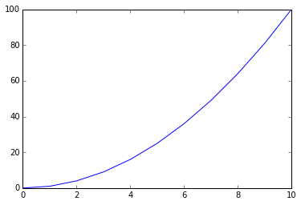

```python
x = np.arange(0,11)
y = x**2
plt.plot(x,y)
plt.show()
```

Bu grafiÄŸi biraz ÅŸenlendirsek ama

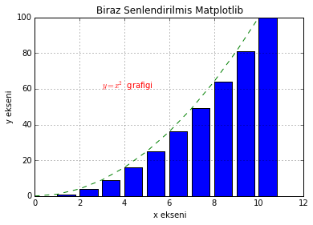

```python
plt.title("Biraz Senlendirilmis Matplotlib")
plt.xlabel("x ekseni")
plt.ylabel("y ekseni")
plt.grid(True)
plt.plot(x, y, 'g--')
plt.bar(x, y)
plt.annotate("$y = x^2$ grafigi", xy=(3, 60), color = 'r')
plt.show()
```

YardÄ±m

Boolean values and comparison operators

Strings

Lists

Tuples and immutable versus mutable objects

Assignment and name binding

If statements

For loops

List comprehensions

While loops

Functions

Function namespaces

Writing scripts

Modules

Timing functions and programs

```python
import time
time.time()
```

```
1424019262.912
```

```python
t1 = time.time()
ComputeEnergies()
t2 = time.time()
```

[output not shown]

```python
import cProfile
cProfile.run("ComputeEnergies()")
```

```
         2 function calls in 0.000 seconds

   Ordered by: standard name

   ncalls  tottime  percall  cumtime  percall filename:lineno(function)
        1    0.000    0.000    0.000    0.000 <string>:1(<module>)
        1    0.000    0.000    0.000    0.000 {method 'disable' of '_lsprof.Profiler' objects}
```

[output not shown]

# Python Nesne Yönelimli Programlama

Python Python enforces a great democracy: everything in it—values, lists, classes, and functions—are objects. An object comes with multiple properties and functions that can accessed using dot notation. For example,

```python
s = "hello"
s.capitalize()
s.replace("lo", "p")
```

```
'help'
```

We could have used dot notation directly on the string itself:

```python
"hello".capitalize()
```

```
'Hello'
```

The fact that everything is an object has great advantages for programming flexibility. Any object can be passed to a function; one can send values or arrays, for example, but it is equally easy to send other functions as arguments to functions. Moreover, almost everything in Python can be packaged up and saved to a file, since there are generic routines that pack and unpack objects into strings.

# python-control-flow

A simple while loop -- notice the indentation to denote the block that is part of the loop.

```python
n = 0
while n < 10:
    print n
    n += 1
```

```
0
1
2
3
4
5
6
7
8
9
```

if allows for branching. python does not have a select/case statement

```python
x = 10
if x < 0:
    print "negative"
elif x == 0:
    print "zero"
else:
    print "positive"
```

```
positive
```

it's easy to loop over items in a list

```python
alist = [1, 2.0, "three", 4]
for a in alist:
    print a
```

```
1
2.0
three
4
```

and break out of the loop when you find what you're looking for

```python
n = 0
for a in alist:
    if a == "three":
        break
    else:
        n += 1

print n
```

```
2
```

(for that example, however, there is a simpler way)

```python
print alist.index("three")
```

```
2
```

for dictionaries, you can also loop over the elements

```python
myDict = {"key1":1, "key2":2, "key3":3}

for k, v in myDict.iteritems():
    print "key = %s, value = %s" % (`k`, `v`)    # notice how we do the formatting here
```

```
key = 'key3', value = 3
key = 'key2', value = 2
key = 'key1', value = 1
```

```python
Pitonlar pandalar ne oluyor
```

```
  File "<ipython-input-72-0e87ba3fb057>", line 1
    Pitonlar pandalar ne oluyor
                    ^
SyntaxError: invalid syntax
```

###### *Python' la muhabbetiniz bol olsun. YalnÄ±z bu iliÅŸki tek taraflÄ± olmaz. UnutmayÄ±n kaynak sizsiniz!.*